# Major Steps in Exploratory Data Analysis (EDA)

## SHAP + XGBoost

```python
# 1. Define model features: remove raw text/date columns that shouldn't go into model
feat_cols = X_train.columns.difference(["clinical_sheet", "int_date", "match_diag_141"])
Xtr = X_train[feat_cols]
ytr = y_train.astype(int)

# 2. Train a small XGBoost model (fast, no early stopping needed)
dtrain = xgb.DMatrix(Xtr, label=ytr)
params = {
    "objective": "binary:logistic",
    "eval_metric": "aucpr",         # useful in imbalanced settings
    "tree_method": "hist",          # fast histogram-based growth
    "learning_rate": 0.05,
    "max_depth": 10,
    "subsample": 0.8,
    "colsample_bytree": 0.8,
    "random_state": 42,
}
model = xgb.train(params, dtrain, num_boost_round=400)

# 3. Stratified sample to reduce SHAP runtime
def strat_sample(X, y, n=1500, seed=42):
    """Return a stratified subset of size n (or fewer if dataset is smaller)."""
    n = min(n, len(X))
    sss = StratifiedShuffleSplit(n_splits=1, test_size=n, random_state=seed)
    _, idx = next(sss.split(X, y))
    return X.iloc[idx], y.iloc[idx]

X_bg_raw,  _ = strat_sample(X_train, y_train, n=800,  seed=42)   # background sample
X_eval_raw, _ = strat_sample(X_val,   y_val,   n=1500, seed=24)   # rows to explain
X_bg   = X_bg_raw[feat_cols]
X_eval = X_eval_raw[feat_cols]
print(f"SHAP background={len(X_bg)}, eval={len(X_eval)}")

# 4. Run SHAP explainer (interventional uses model input distribution)
explainer   = shap.TreeExplainer(model, data=X_bg, feature_perturbation="interventional")
shap_values = explainer.shap_values(X_eval)
```

```
SHAP background=800, eval=1500
```

```
 97%|=================== | 1451/1500 [00:43<00:01]
```

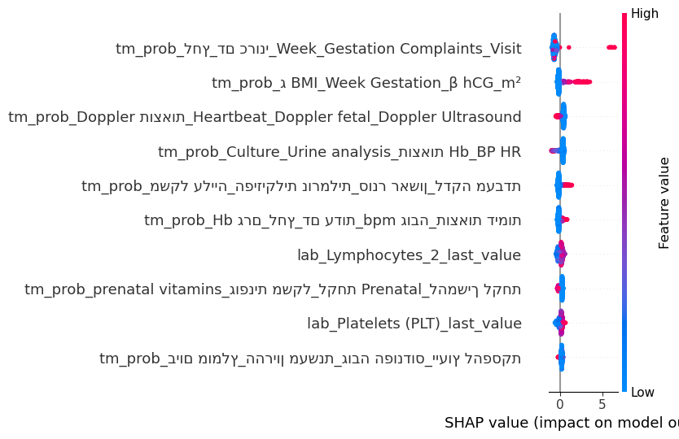

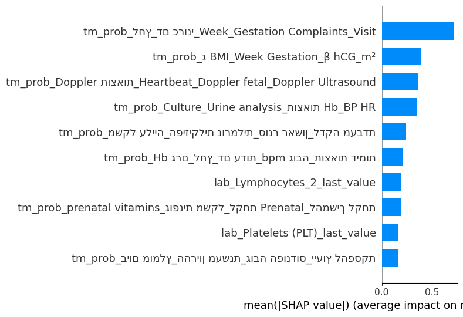

|  | feature | mean_abs_SHAP |
| --- | --- | --- |
| 0 | tm_prob_לחץ_דם כרוני_Week_Gestation Complaints... | 0.723814 |
| 1 | tm_prob_ג BMI_Week Gestation_β hCG_m² | 0.394711 |
| 2 | tm_prob_Doppler תוצאות_Heartbeat_Doppler fetal... | 0.368630 |
| 3 | tm_prob_Culture_Urine analysis_תוצאות Hb_BP HR | 0.347231 |
| 4 | tm_prob_משקל עלייה_הפיזיקלית נורמלית_סונר ראשו... | 0.246086 |
| 5 | tm_prob_Hb גרם_לחץ_דם עדות_bpm גובה_תוצאות דימות | 0.212273 |
| 6 | lab_Lymphocytes_2_last_value | 0.198746 |
| 7 | tm_prob_prenatal vitamins_גופנית משקל_לקחת Pre... | 0.190023 |
| 8 | lab_Platelets (PLT)_last_value | 0.164411 |
| 9 | tm_prob_ביום מומלץ_ההריון מעשנת_גובה הפונדוס_י... | 0.163567 |
| 10 | lab_Monocytes_2_last_value | 0.155048 |
| 11 | tm_prob_אחת ביום_לשבועות הגיל_להפסיק_עקב הסיכון | 0.147079 |
| 12 | tm_prob_Doppler תוצאות_יצאו בגדר_אפשרי אין_תפק... | 0.146675 |
| 13 | measure_blood_pressure_dias_min_val | 0.139486 |
| 14 | demog_capitationcoefficient | 0.139135 |
| 15 | tm_prob_סיכונים ודגשים_וגובה נמדדו_אפשריים BMI... | 0.137033 |
| 16 | lab_papp_a_MoM_last_value | 0.136090 |
| 17 | measure_blood_pressure_sys_last_val | 0.134622 |
| 18 | tm_prob_גופניות בבדיקה_רמות hCG_פיזיקלית אין_ת... | 0.129237 |
| 19 | tm_prob_Prenatal Vitamins_ממצאי הרחם_Iron_נשמע... | 0.126034 |
| 20 | tm_prob_g אין_תוצאות Blood_לדקה עלייה_רמות Hem... | 0.125360 |
| 21 | lab_papp_a_abs_last_value | 0.124483 |
| 22 | tm_prob_ד דופק_Urinalysis תקין_רמות Hemoglobin... | 0.122212 |
| 23 | lab_Mean Corpuscular Hemoglobin (MCH)_last_value | 0.119304 |
| 24 | measure_blood_pressure_dias_count | 0.118474 |
| 25 | tm_prob_סיכום ורשמים_לדקה בטן_לחץ_דם ממ_תקין ב... | 0.117401 |
| 26 | lab_b_hcg_abs_last_value | 0.115882 |
| 27 | lab_Mean Platelet Volume (MPV)_last_value | 0.115672 |
| 28 | lab_weight_at_lab_time_last_value | 0.112042 |
| 29 | lab_Red Cell Distribution Width (RDW)_last_value | 0.109701 |

```python
# 5. SHAP Visualizations
import matplotlib.pyplot as plt

plt.figure(figsize=(15, 8))  # Width x Height
shap.summary_plot(shap_values, X_eval, show=True, max_display=10)
shap.summary_plot(shap_values, X_eval, plot_type="bar", show=True, max_display=10)  # mean(|SHAP|)

# 6. Table of top features by mean absolute SHAP value
mean_abs = np.abs(shap_values).mean(axis=0)
top_idx  = np.argsort(-mean_abs)[:30]
top_features_df = pd.DataFrame({
    "feature": X_eval.columns[top_idx],
    "mean_abs_SHAP": mean_abs[top_idx]
}).reset_index(drop=True)
display(top_features_df)
```

#### Based on SHAP summary plots and table, here are the **key findings** from the model explainability analysis.

#### Top Influential Features (SHAP Mean > 0.3)

These features had the **strongest average impact** on the model's output:

[output not shown]

**Interpretation**: These topics are **strong health indicators**—blood pressure, ultrasound, BMI, hCG—all are relevant for high-risk pregnancy detection or patient condition evaluation.

#### Moderately Important Features (SHAP Mean 0.15–0.3)

These features are **still important** but with lower contribution:

[output not shown]

**Interpretation**: These include **clinical notes**, **fundal height**, and **habits like smoking**, which are also essential for risk prediction but not as dominant as the top 4.

#### Lab Features with Moderate Contribution

Some **lab measurements** (not topics) also appeared:

[output not shown]

#### General Takeaways

**Topic probabilities (`tm_prob_*`) dominate the top features** — indicating your BERT-topic modeling has successfully extracted **meaningful patterns** from clinical notes.

##### SHAP Force Plot (Explanation per Individual)

#### Purpose & Motivation

- Helps explain **why** the model made a specific prediction for **one individual**.
- Shows which features pushed the prediction **higher** or **lower** compared to the **base value**.
- Useful for personalized explanations in **medical** or **risk** models.

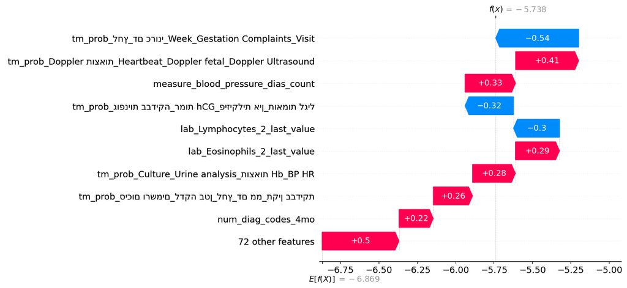

```python
shap.plots._waterfall.waterfall_legacy(
    expected_value=explainer.expected_value,          # scalar base value
    shap_values=shap_values[496],                     # 1D array of shap values
    features=X_test[feat_cols].iloc[496].values,      # 1D array of feature values
    feature_names=X_test[feat_cols].columns.tolist(), # list of names
    max_display=10                                    # top 10 features
)
```